# OCN683_HW1

ʻAʻaliʻi Kelling

2025-01-22

```r
#load R packages
library(tidyverse)
library(car)
library(janitor) #cleaning data function
library(here) #enables easy file referencing
library(rstatix) #descriptive stats
```

```r
library(ggeffects) #effects plot
library(ggplot2)
```

#Introduction

```r
#Load data

bird <- read_csv("foraging.height.edit (1).csv")
```

```
## ──────────────────────────────────────────────────────── Delimiter: "," chr
## (6): SPECIES, Kipuka, Rat_Removal, DATE, OBSERVER, dietary.grouping dbl (6):
## ...1, Area_ha, Elevation_m, Year, tot.arth.bm, foraging.ht.m
```

```r
head(bird)
```

```
## # A tibble: 6 × 12
##    ...1 SPECIES Kipuka Area_ha Elevation_m Rat_Removal DATE    OBSERVER  Year
##   <dbl> <chr>   <chr>    <dbl>       <dbl> <chr>       <chr>   <chr>    <dbl>
## 1     1 JAWE    K13       0.1         1575 treated     1/28/12 JK        2012
## 2     2 HAAM    K13       0.1         1575 treated     1/23/12 NF        2012
## 3     3 IIWI    K5       10.5         1632 treated     1/22/12 WK        2012
## 4     4 HAAM    K5       10.5         1632 treated     1/22/12 WK        2012
## 5     5 APAP    K5       10.5         1632 treated     1/22/12 WK        2012
## 6     6 APAP    K36       0.19        1757 treated     1/20/12 JK        2012
## # ℹ 3 more variables: tot.arth.bm <dbl>, dietary.grouping <chr>,
## #   foraging.ht.m <dbl>
```

```r
#Clean data using janitor package
str(bird)
```

```
## spc_tbl_ [527 × 12] (S3: spec_tbl_df/tbl_df/tbl/data.frame)
##  $ ...1            : num [1:527] 1 2 3 4 5 6 7 8 9 10 ...
##  $ SPECIES         : chr [1:527] "JAWE" "HAAM" "IIWI" "HAAM" ...
##  $ Kipuka          : chr [1:527] "K13" "K13" "K5" "K5" ...
##  $ Area_ha         : num [1:527] 0.1 0.1 10.5 10.5 10.5 ...
##  $ Elevation_m     : num [1:527] 1575 1575 1632 1632 1632 ...
##  $ Rat_Removal     : chr [1:527] "treated" "treated" "treated" "treated" ...
##  $ DATE            : chr [1:527] "1/28/12" "1/23/12" "1/22/12" "1/22/12" ...
##  $ OBSERVER        : chr [1:527] "JK" "NF" "WK" "WK" ...
##  $ Year            : num [1:527] 2012 2012 2012 2012 2012 ...
##  $ tot.arth.bm     : num [1:527] 1.16 1.16 149.63 149.63 149.63 ...
##  $ dietary.grouping: chr [1:527] "frugivore" "insectivore" "nectarivore" "insectivore" ...
##  $ foraging.ht.m   : num [1:527] 2.24 2.74 4.15 4.65 5.15 ...
##  - attr(*, "spec")=
##   .. cols(
##   ..   ...1 = col_double(),
##   ..   SPECIES = col_character(),
##   ..   Kipuka = col_character(),
##   ..   Area_ha = col_double(),
##   ..   Elevation_m = col_double(),
##   ..   Rat_Removal = col_character(),
##   ..   DATE = col_character(),
##   ..   OBSERVER = col_character(),
##   ..   Year = col_double(),
##   ..   tot.arth.bm = col_double(),
##   ..   dietary.grouping = col_character(),
##   ..   foraging.ht.m = col_double()
##   .. )
##  - attr(*, "problems")=<externalptr>
```

```r
bird <- clean_names(bird) #fix column names


bird <- bird %>%
  select (-x1) %>%  #removing first column X
  mutate(date = mdy(date)) %>%
  mutate(species = as.factor(species)) %>% #correct variable types
  mutate(kipuka = as.factor(kipuka)) %>%
  mutate(rat_removal = as.factor(rat_removal)) %>%
  mutate(dietary_grouping = as.factor(dietary_grouping))

str(bird)
```

```
## tibble [527 × 11] (S3: tbl_df/tbl/data.frame)
##  $ species         : Factor w/ 6 levels "APAP","HAAM",..: 5 2 4 2 1 1 1 1 1 1 ...
##  $ kipuka          : Factor w/ 30 levels "K10","K12","K13",..: 3 3 28 28 28 24 2 12 24 24 ...
##  $ area_ha         : num [1:527] 0.1 0.1 10.5 10.5 10.5 ...
##  $ elevation_m     : num [1:527] 1575 1575 1632 1632 1632 ...
##  $ rat_removal     : Factor w/ 2 levels "treated","untreated": 1 1 1 1 1 1 1 1 1 1 ...
##  $ date            : Date[1:527], format: "2012-01-28" "2012-01-23" ...
##  $ observer        : chr [1:527] "JK" "NF" "WK" "WK" ...
##  $ year            : num [1:527] 2012 2012 2012 2012 2012 ...
##  $ tot_arth_bm     : num [1:527] 1.16 1.16 149.63 149.63 149.63 ...
##  $ dietary_grouping: Factor w/ 3 levels "frugivore","insectivore",..: 1 2 3 2 3 3 3 3 3 3 ...
##  $ foraging_ht_m   : num [1:527] 2.24 2.74 4.15 4.65 5.15 ...
```

## (1) Start with some data exploration. How many observations are there of each bird species in each experimental treatment? Make a boxplot or violinplot to show the distribution of foraging heights of each bird species in each experimental treatment.

For the ʻApapane (APAP), there are 131 observations in the treated group and 188 observations in the untreated group. For the Hawaiʻi ʻAmakihi (HAAM), there are 47 observations in the treated group and 42 observations in the untreated group. For the ʻIʻiwi (IIWI), there are 30 observations in the treated group and 43 observations in the untreated group. Finally, for Japanese White-eye (JAWE), there are 16 observations in the treated group and 9 observations in the untreated group. Shown below is the boxplot and table of species by treatment.

```r
#remove other species we don't care about
bird <- bird %>%
  filter(!species %in% c("HAEL", "OMAO"))

# summarize per species and get total observations
bird_count <- bird %>%
  group_by(species, rat_removal) %>%
  summarise(n = n())
bird_count
```

```
## # A tibble: 8 × 3
## # Groups:   species [4]
##   species rat_removal     n
##   <fct>   <fct>       <int>
## 1 APAP    treated       131
## 2 APAP    untreated     188
## 3 HAAM    treated        47
## 4 HAAM    untreated      42
## 5 IIWI    treated        30
## 6 IIWI    untreated      43
## 7 JAWE    treated        16
## 8 JAWE    untreated       9
```

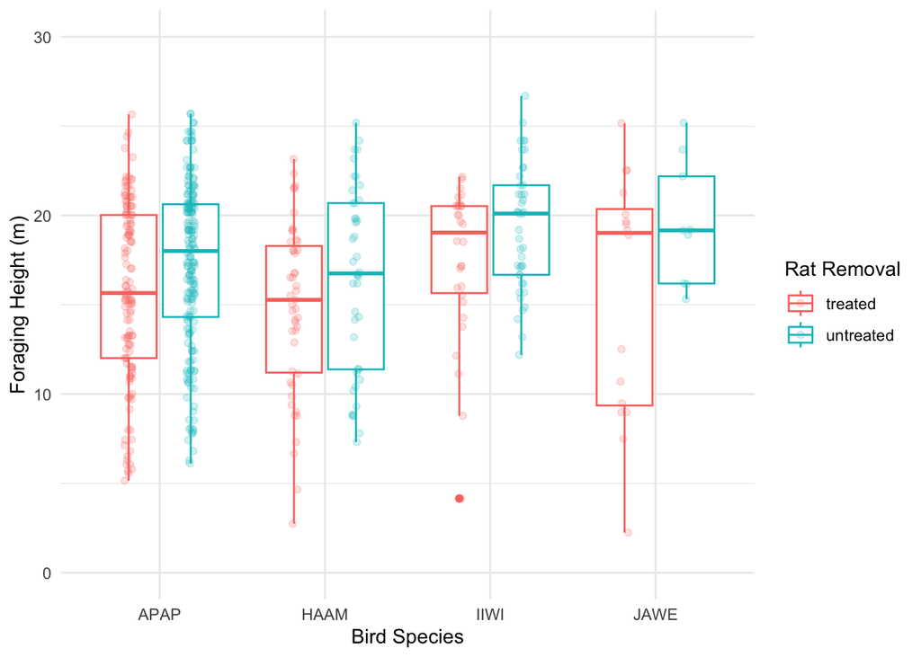

```r
#Data Visualization
ggplot(bird) +
  geom_boxplot(aes(x = species, y = foraging_ht_m, color = rat_removal)) +
  geom_jitter(aes(x = species, y = foraging_ht_m, color = rat_removal), alpha = 0.2,
              position = position_jitterdodge(jitter.width = 0.1)) +
  ylim(0, 30) +
  labs(
    x = "Bird Species",
    y = "Foraging Height (m)",
    color = "Rat Removal"
  ) +
  theme_minimal()
```

##(1) What have you learned so far?

##(2) Now make a plot showing the mean foraging height of each bird species in eachtreatment, and include error bars displaying +/- one standard error of the mean.

```r
#Descriptive stats for mean foraging height and se of mean
summary_stats <- bird %>%
  group_by(species, rat_removal) %>%
  summarise(
    mean_height = mean(foraging_ht_m),
    sem_height = sd(foraging_ht_m) / sqrt(n())
    )
summary_stats
```

```
## # A tibble: 8 × 4
## # Groups:   species [4]
##   species rat_removal mean_height sem_height
##   <fct>   <fct>             <dbl>      <dbl>
## 1 APAP    treated            15.7      0.436
## 2 APAP    untreated          17.3      0.336
## 3 HAAM    treated            14.8      0.697
## 4 HAAM    untreated          16.5      0.803
## 5 IIWI    treated            17.5      0.777
## 6 IIWI    untreated          19.3      0.534
## 7 JAWE    treated            15.6      1.70
## 8 JAWE    untreated          19.6      1.16
```

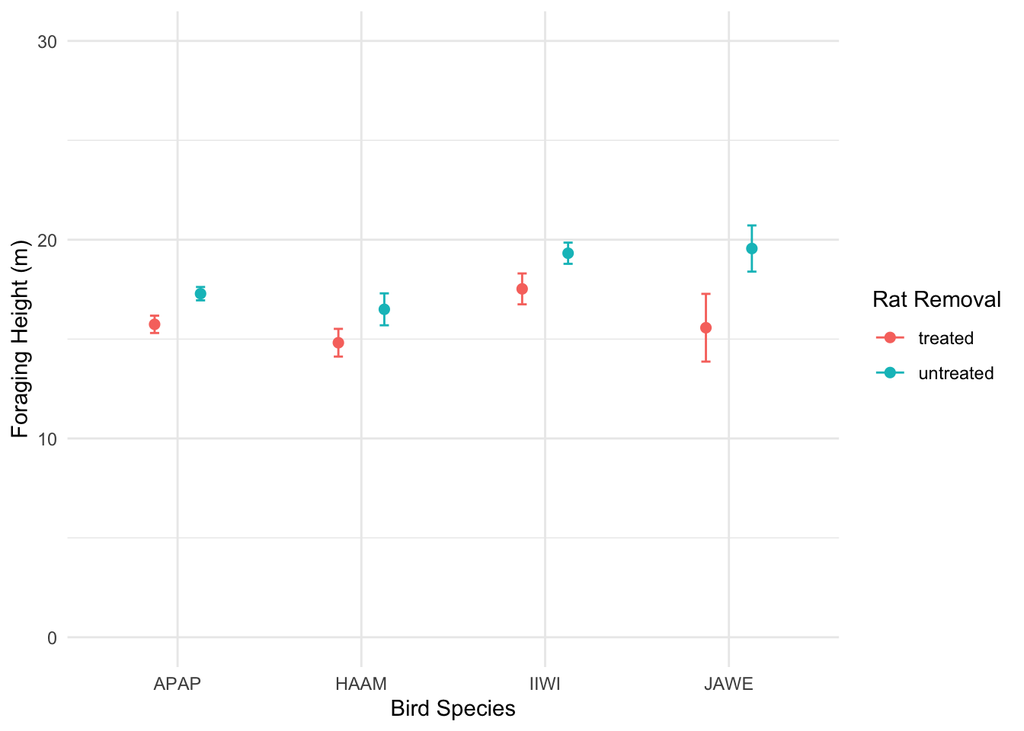

```r
#Plot
# Standard error of the mean
pd <- position_dodge(0.5) #stagger points on plot

ggplot(summary_stats, aes(x = species, y = mean_height, color = rat_removal)) +
  geom_point(position = pd, size = 2) +
  geom_errorbar(aes(ymin = mean_height - sem_height, ymax = mean_height + sem_height),
                width = 0.1, position = pd) +
  ylim(0, 30) +
  labs(
    x = "Bird Species",
    y = "Foraging Height (m)",
    color = "Rat Removal"
  ) +
  theme_minimal()
```

##(2) What is the meaning of the standard error of the mean? How does this plot differ from the plot in #1?

The standard error of the mean (SEM) indicates how confident we can be that the sample mean represents the population mean. Smaller SEM values mean higher confidence and more precise estimates. This plot (2) focuses on the SEM to summarize the reliability of the means, while the first plot illustrates the spread and variability of the raw data points, showing individual data values rather than a summary statistic like SEM.

## (3) Fit a linear model that tests whether the bird species differ in foraging height, whether the rat removal treatment affects foraging height, and whether the effect of the rat removal differs between the bird species. Make plots to assess the distribution of the residuals. Report F-tests for the terms of the model.

```r
#linear model for species
lm_foragingheights <- lm(foraging_ht_m ~ species * rat_removal, data = bird)
summary(lm_foragingheights)
```

```
##
## Call:
## lm(formula = foraging_ht_m ~ species * rat_removal, data = bird)
##
## Residuals:
##      Min       1Q   Median       3Q      Max
## -13.3712  -3.2434   0.4048   3.5558   9.9124
##
## Coefficients:
##                                  Estimate Std. Error t value Pr(>|t|)
## (Intercept)                       15.7426     0.4145  37.980  < 2e-16 ***
## speciesHAAM                       -0.9253     0.8067  -1.147  0.25192
## speciesIIWI                        1.7836     0.9602   1.857  0.06384 .
## speciesJAWE                       -0.1713     1.2564  -0.136  0.89158
## rat_removaluntreated               1.5426     0.5399   2.857  0.00446 **
## speciesHAAM:rat_removaluntreated   0.1377     1.1429   0.120  0.90414
## speciesIIWI:rat_removaluntreated   0.2512     1.2511   0.201  0.84097
## speciesJAWE:rat_removaluntreated   2.4428     2.0492   1.192  0.23378
## ---
## Signif. codes:  0 '***' 0.001 '**' 0.01 '*' 0.05 '.' 0.1 ' ' 1
##
## Residual standard error: 4.744 on 498 degrees of freedom
## Multiple R-squared:  0.06351,    Adjusted R-squared:  0.05034
## F-statistic: 4.824 on 7 and 498 DF,  p-value: 2.838e-05
```

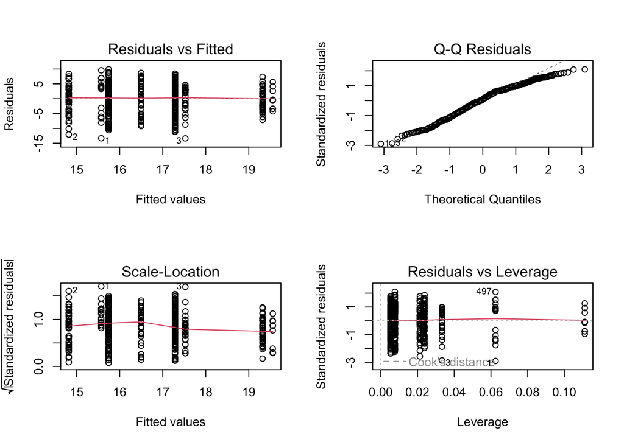

```r
#Check the residuals
par(mfrow = c(2, 2)) # 2x2 plot layout
plot(lm_foragingheights)
```

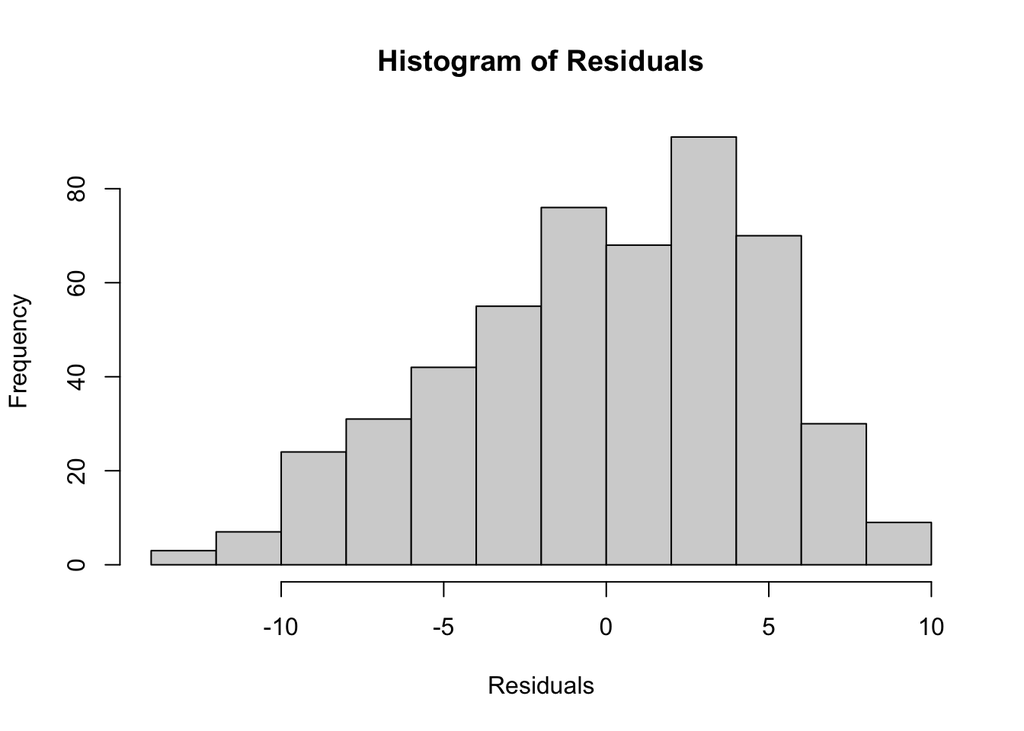

```r
par(mfrow = c(1, 1))
hist(residuals(lm_foragingheights), main = "Histogram of Residuals", xlab = "Residuals")
```

##(3) Report F-tests for the terms of the model. Create an effects plot displaying the fitted effects. How do you interpret the results? What are the magnitudes of the effects?

```r
#ANOVA on lm
aov_lm <- Anova(lm_foragingheights)
Anova(lm_foragingheights)
```

```
## Anova Table (Type II tests)
##
## Response: foraging_ht_m
##                      Sum Sq  Df F value    Pr(>F)
## species               334.4   3  4.9528  0.002136 **
## rat_removal           362.5   1 16.1081 6.903e-05 ***
## species:rat_removal    32.1   3  0.4757  0.699318
## Residuals           11208.7 498
## ---
## Signif. codes:  0 '***' 0.001 '**' 0.01 '*' 0.05 '.' 0.1 ' ' 1
```

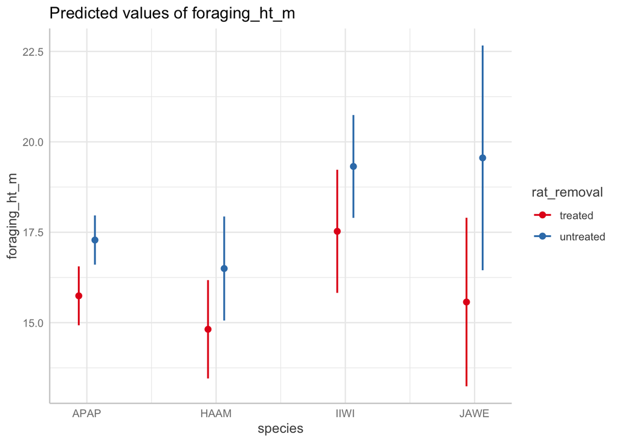

```r
# Plot the effects
plot(ggeffect(lm_foragingheights, terms = c('species', 'rat_removal')))
```

The F tests for the terms of the model include: - Species (F=4.9528, p=0.002) - rat_removal (F=16.1081, p=<0.001) - species:rat_removal (f=0.4757, p=0.699318)

The magnitude of these effects can be seen in the sum of squares from the ANOVA table. Rat removal has a larger sum of squares (SS=362.5) compared to species (SS=334.4), meaning that rat removal has a stronger influence on foraging heights than the differences between species. The interaction term is not significant (p=0.6993), suggesting that the effects of species and rat removal are independent and do not vary based on their combination.

## (4) Kipuka area and arthopod biomass are both continuous predictors – before you add them to the model, make some scatterplots to assess whether these predictors should be transformed when including them in the model. When assessing predictors for transformation, it doesn’t matter if the predictors are normally distributed (this only matters for the response variable) – what matters is whether the predictors are very skewed, such that a few outlying points will have a large influence on a fitted regression line. For skewed predictors, a log or square root transformation will generally help.

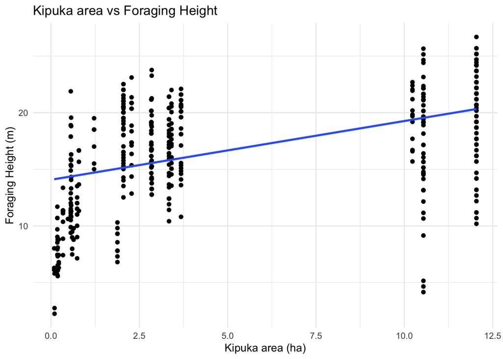

```r
#Scatter plot of Kipuka vs Foraging height
ggplot(bird) +
  geom_point(aes(x = area_ha, y = foraging_ht_m)) +
  geom_smooth(aes(x = area_ha, y = foraging_ht_m),
              method = "lm", se = FALSE)  +
  labs(
    x = "Kipuka area (ha)",
    y = "Foraging Height (m)",
    title = "Kipuka area vs Foraging Height"
  ) +
  theme_minimal()
```

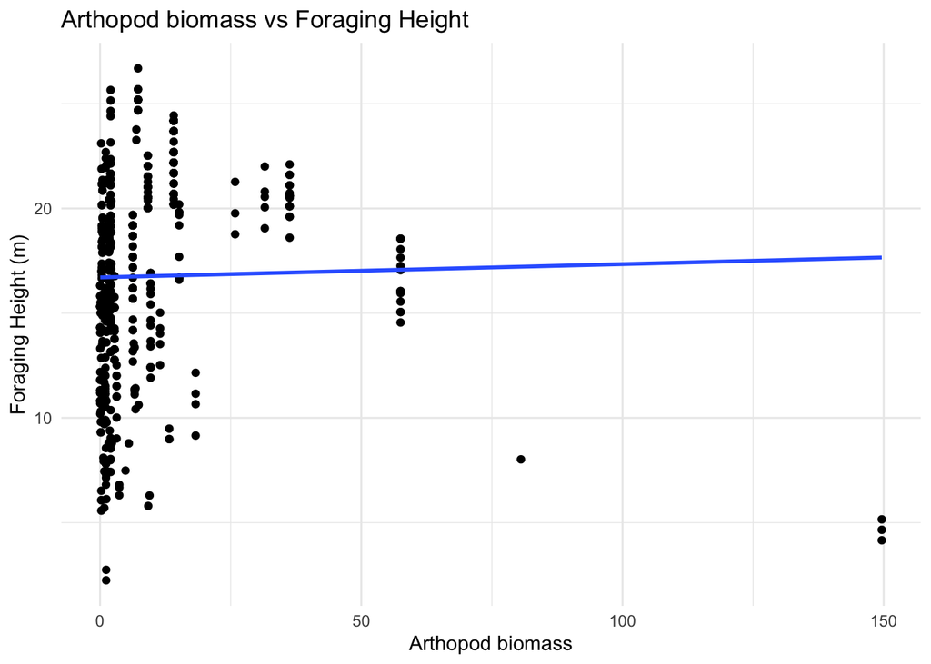

```r
#Scatter plot of arthropod biomass vs Foraging height
ggplot(bird) +
  geom_point(aes(x = tot_arth_bm, y = foraging_ht_m)) +
  geom_smooth(aes(x = tot_arth_bm, y = foraging_ht_m),
              method = "lm", se = FALSE)  +
  labs(
    x = "Arthopod biomass",
    y = "Foraging Height (m)",
    title = "Arthopod biomass vs Foraging Height"
  ) +
  theme_minimal()
```

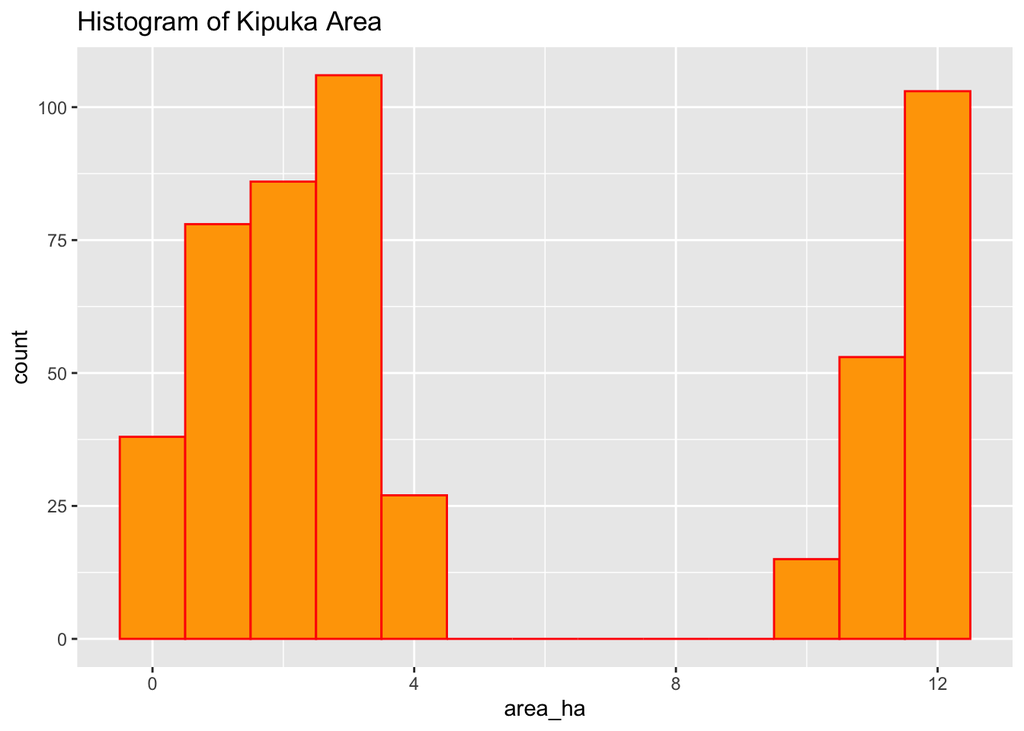

```r
#closer look using histograms
ggplot(bird) +
  geom_histogram(aes(x = area_ha), fill = "orange", color = "red", binwidth = 1) +
  labs(title = "Histogram of Kipuka Area")
```